# Chapter 13 Notes

**Chapter 13 Notes - Chemical Equilibrium**

**Chemical equilibrium**: The state where the concentrations of reactants and products remain constant with time.

**Law of mass action**: states that for a reaction jA + kB <=> lC + mD , the **equilibrium constant** K = [C]<sup>l</sup>[D]<sup>m</sup> / [A]<sup>j</sup>[B]<sup>k</sup> , where the square brackets represent the concentrations of the chemical species *at equilibrium*.

**Equilibrium position**: A particular set of equilibrium concentrations (there are infinitely many that satisfy K).

**Homogeneous equilibria**: equilibria for systems where all products and reactants are in the gas phase.

**Heterogeneous equilibria**: equilibria that involve more than one phase.

*If pure solids of pure liquids are involved in a chemical reaction, their concentrations are not included in the equilibrium expression for the reaction.*

The inherent tendency of a reaction to occur is indicated by the magnitude of the equilibrium constant. That being said, *a high value of K does not mean equilibrium will be reached quickly.*

**Reaction quotient** (Q): Used to determine the directions of the move towards equilibrium when all initial concentrations are nonzero. Obtained by applying the law of mass action using initial concentrations instead of equilibrium concentrations. The direction is determined by comparing K and Q, for which there are three possible cases:

1. Q = K: Equilibrium
2. Q > K: Initial concentrations of products are too large; the system will shift left to attain equilibrium.
3. Q < K: Initial concentrations of products are too small; the system will shift right to attain equilibrium.

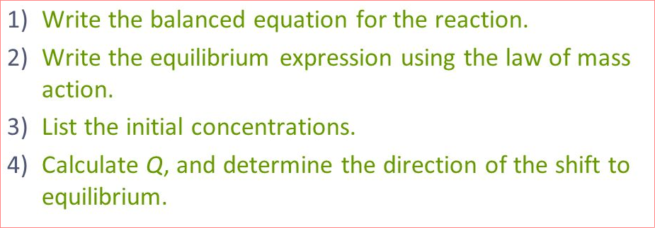

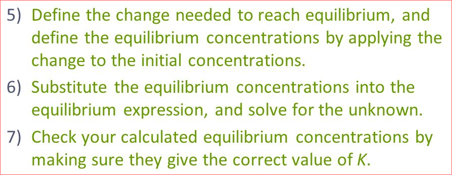

We can qualitatively predict the effects of changes in concentration, pressure, and temperature on a system at equilibrium using **La Chatelier’s principle**, which states that if a change is imposed on a system at equilibrium, the position of the equilibrium will shift in a direction that tends to reduce that change. Or, if a component is added to a reaction system at equilibrium (at a constant T and P or constant T and V), the position of the equilibrium will shift in the direction that lowers the concentration of that component.

Kc is the equilibrium constant for concentrations (often just K is used)

Kp is the equilibrium constant for atmospheric pressure.

Kc = Kp / (RT)<sup>Δn</sup> , where Δn is the sum of the coefficients of the gaseous products minus the sum of the coefficients of the gaseous reactants. For example, in

N<sub>2</sub>(g) + 3H<sub>2</sub>(g) <-> 2NH<sub>3</sub>(g) , Δn = (2) - (3 + 1) = -2.

R = 0.08206 L*atm / mol*K .